# **Used Cars Price Prediction**

## **Univariate Analysis**

**Questions:**

1. Do univariate analysis for numerical and categorical variables?
2. Check the distribution of the different variables? is the distributions skewed?
3. Do we need to do log_transformation, if so for what variables we need to do?
4. Perfoem the log_transformation(if needed) and write down your observations?

```python
# Univariate analysis of numerical columns:
distro = data[num_cols].describe().T
print(distro)
```

```
                    count          mean           std      min           25%  \
year               7200.0   2013.391111      3.235118  1996.00   2011.000000
kilometers_driven  7200.0  58628.546111  84683.269158   171.00  34000.000000
mileage            7200.0     18.355059      4.144229     6.40     15.400000
engine             7200.0   1616.710972    595.234346    72.00   1198.000000
power              7200.0    112.772241     53.037124    34.20     76.800000
new_price          7200.0     22.779692     10.371848     3.91     22.779692
price              7200.0      9.498817     10.208070     0.44      3.877500

                            50%           75%         max
year                2014.000000   2016.000000     2019.00
kilometers_driven  53226.000000  73000.000000  6500000.00
mileage               18.355059     21.100000       33.54
engine              1493.000000   1968.000000     5998.00
power                 98.600000    138.030000      616.00
new_price             22.779692     22.779692      375.00
price                  6.750000      9.479468      160.00
```

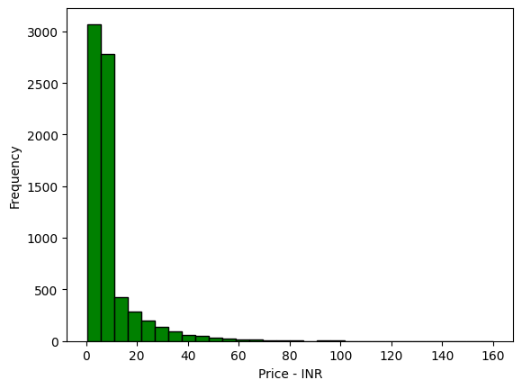

```python
# Our Target Dependant Variable is "price"...
#Distribution of Price:
distrobution = data['price'].plot(kind='hist', bins=30, color='green', edgecolor='black')
plt.xlabel('Price - INR')
plt.ylabel('Frequency')
```

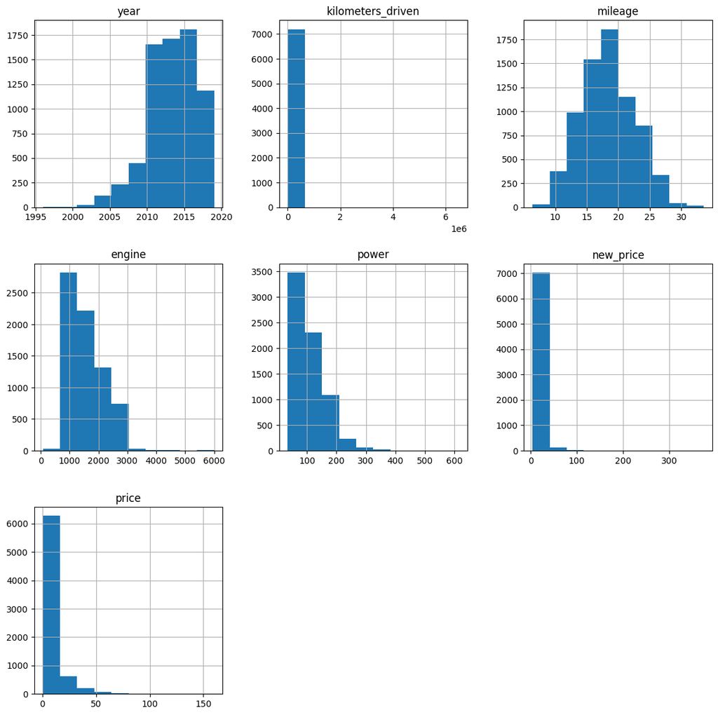

```python
# Creating histograms - here we will look at the distributions for all the individual numerical columns
data[num_cols].hist(figsize = (14, 14))

plt.show()
```

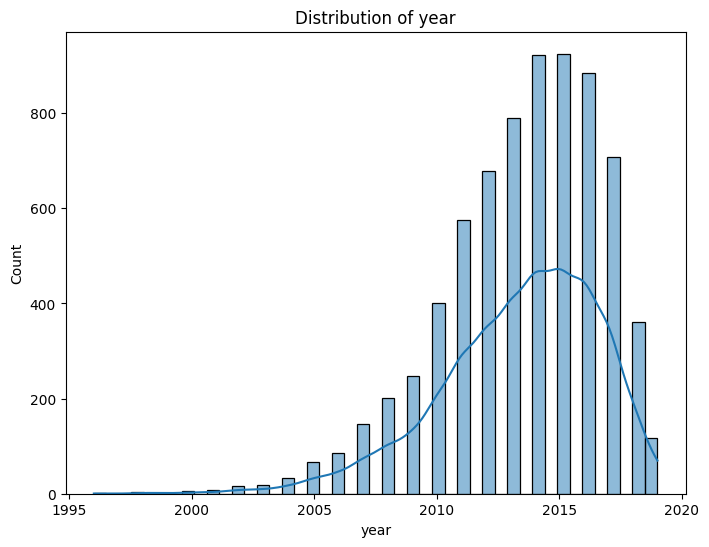

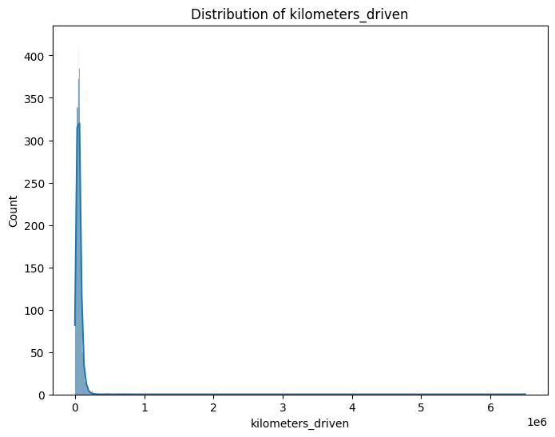

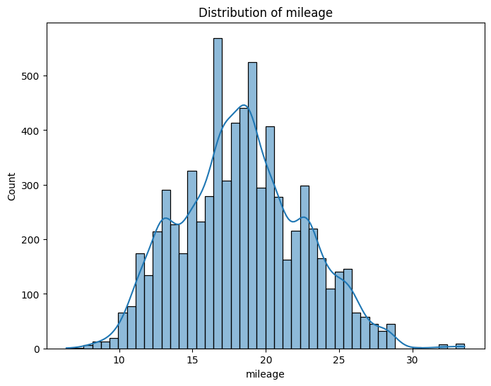

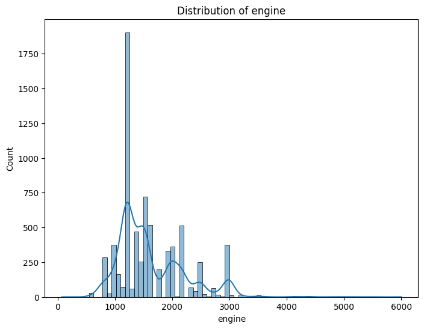

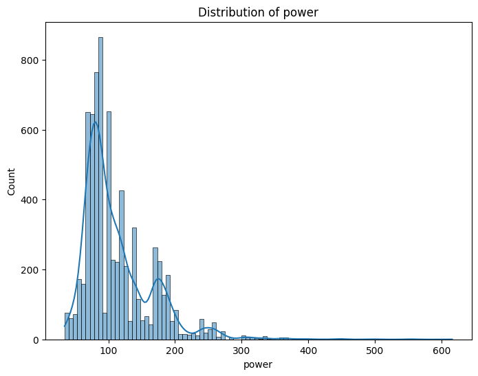

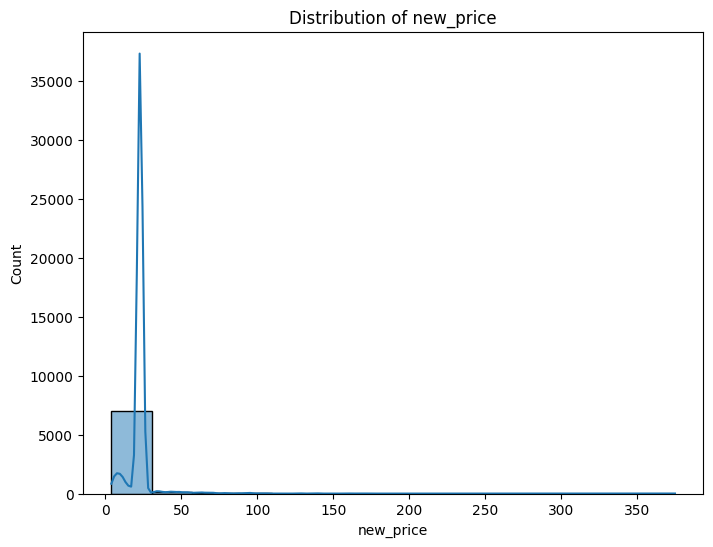

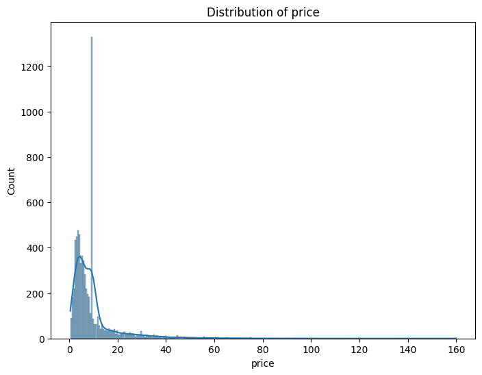

[figure not shown]

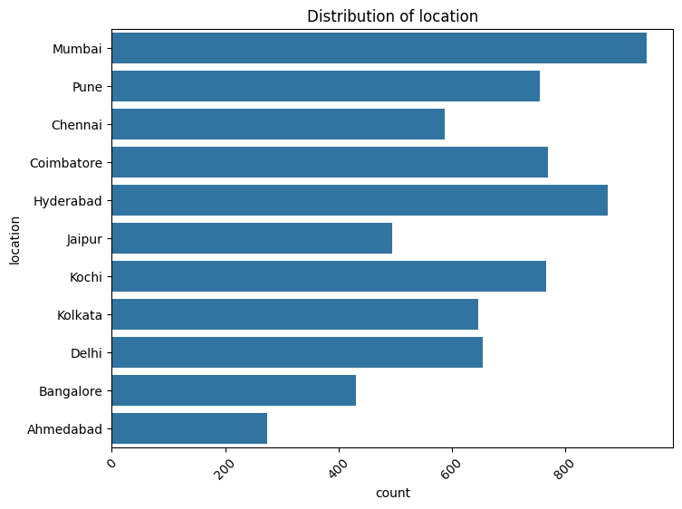

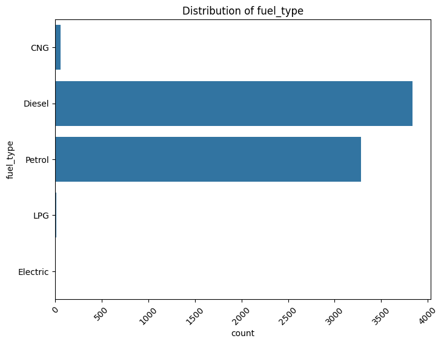

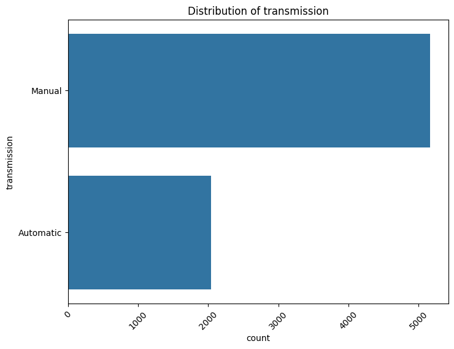

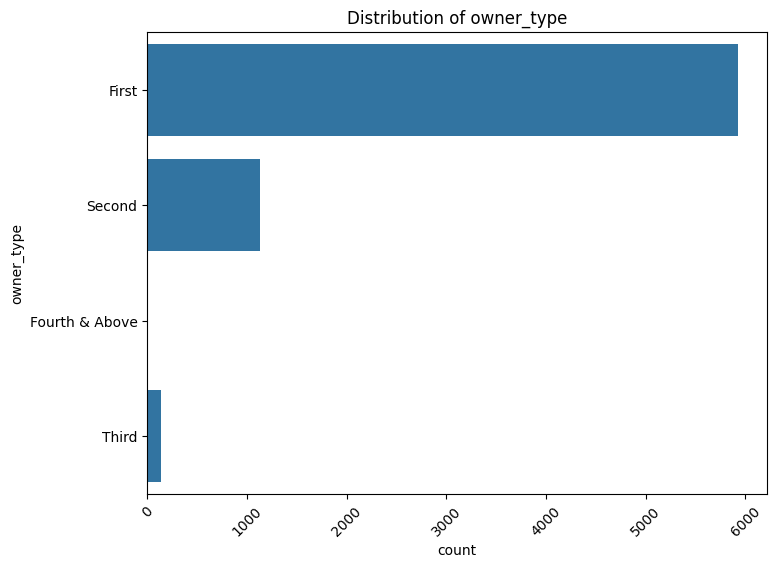

[1 more figures not shown]

```python
# Plot histograms for numerical columns
for col in num_cols:
    plt.figure(figsize=(8, 6))
    sns.histplot(data[col], kde=True)
    plt.title(f'Distribution of {col}')
    plt.show()

# Plot countplots for categorical columns
for col in cat_cols:
    plt.figure(figsize=(8, 6))
    sns.countplot(data[col])
    plt.title(f'Distribution of {col}')
    plt.xticks(rotation=45)
    plt.show()
```

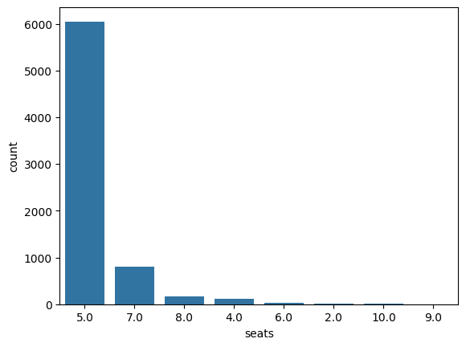

```python
# The plot for Seats looks a little odd above...  So reploting here to better visualize...
sns.countplot(data, x='seats', order=data['seats'].value_counts().index)
```

## **Bivariate Analysis**

**Questions:**

1. Plot a scatter plot for the log transformed values(if log_transformation done in previous steps)?
2. What can we infer form the correlation heatmap? Is there correlation between the dependent and independent variables?
3. Plot a box plot for target variable and categorical variable 'Location' and write your observations?

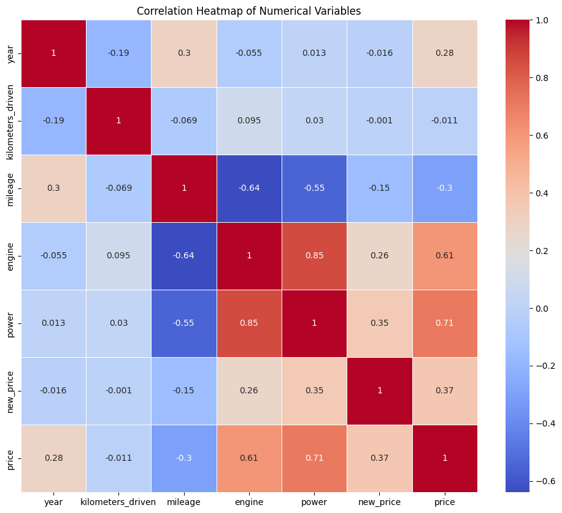

```python
# Next we will create correlation heat maps for all the individual numerical variables:
plt.figure(figsize=(12, 10))
correlation_matrix = data[num_cols].corr()
sns.heatmap(correlation_matrix, annot=True, cmap='coolwarm', linewidths=0.5)
plt.title('Correlation Heatmap of Numerical Variables')
plt.show()
```

```python
print(correlation_matrix)
```

```
                       year  kilometers_driven   mileage    engine     power  \
year               1.000000          -0.187090  0.295468 -0.055114  0.013020
kilometers_driven -0.187090           1.000000 -0.068891  0.094537  0.030076
mileage            0.295468          -0.068891  1.000000 -0.639398 -0.545934
engine            -0.055114           0.094537 -0.639398  1.000000  0.853516
power              0.013020           0.030076 -0.545934  0.853516  1.000000
new_price         -0.015889          -0.001032 -0.147763  0.264430  0.352775
price              0.279613          -0.011105 -0.303798  0.606174  0.705635

                   new_price     price
year               -0.015889  0.279613
kilometers_driven  -0.001032 -0.011105
mileage            -0.147763 -0.303798
engine              0.264430  0.606174
power               0.352775  0.705635
new_price           1.000000  0.367390
price               0.367390  1.000000
```

```python
# Key observations from the correlation matrix:
# Our Dependent Variable is (car) Price (what we are trying to predict)
# 1. Correlation between dependent variable (price) and independent variables:
print("Correlation between price and other variables:")
for column in correlation_matrix.index:
    if column != 'price':
        correlation = correlation_matrix.loc['price', column]
        print(f"{column}: {correlation:.3f}")

print("\nPotential multicollinearity issues:")
for col1_idx, col1 in enumerate(correlation_matrix.columns):
    for col2 in correlation_matrix.columns[col1_idx + 1 :]:
        if correlation_matrix.loc[col1, col2] > 0.8:
            print(
                f"High correlation ({correlation_matrix.loc[col1, col2]:.2f}) between '{col1}' and '{col2}' - potential multicollinearity issue."
            )

print("\nOther statistical observations:")

highest_pos_corr_col = correlation_matrix["price"].nlargest(2).index[1]
print(
    f"Highest positive correlation with price: {correlation_matrix.loc['price', highest_pos_corr_col]:.3f} ({highest_pos_corr_col})"
)

highest_neg_corr_col = correlation_matrix["price"].nsmallest(2).index[1]
print(
    f"Highest negative correlation with price: {correlation_matrix.loc['price', highest_neg_corr_col]:.3f} ({highest_neg_corr_col})"
)

near_zero_corr_cols = correlation_matrix[
    (correlation_matrix["price"].abs() < 0.1) & (correlation_matrix.index != "price")
].index
print(
    f"Variables with near-zero correlation with price: {', '.join(near_zero_corr_cols)}"
)
```

[output not shown]

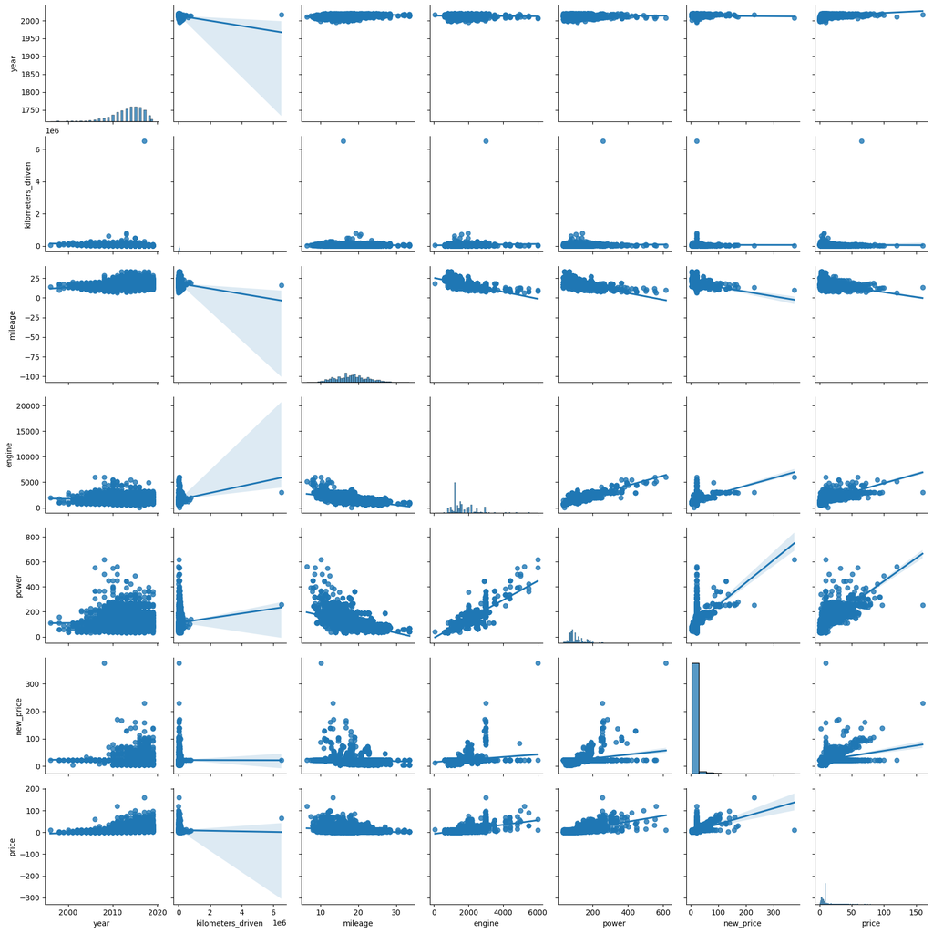

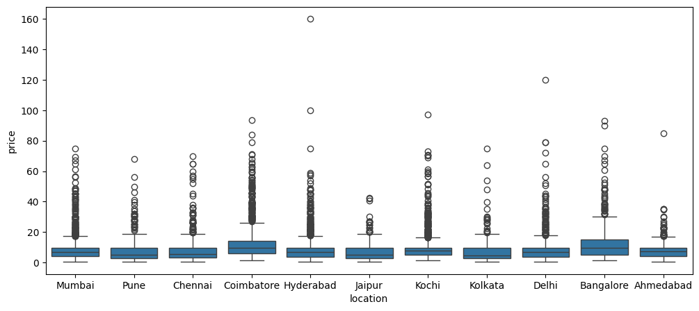

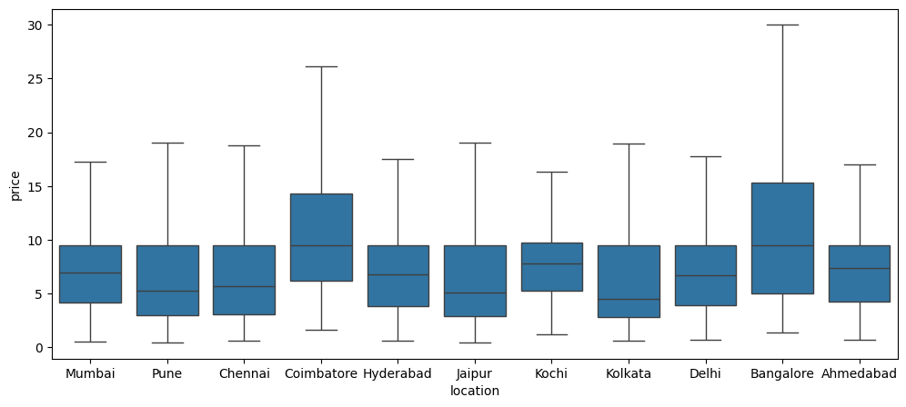

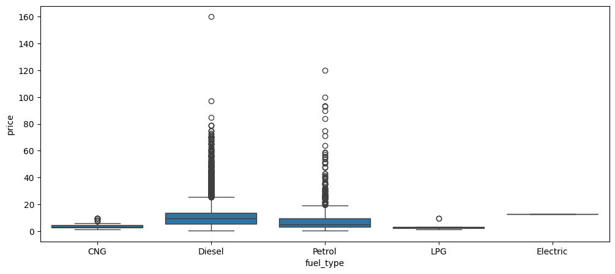

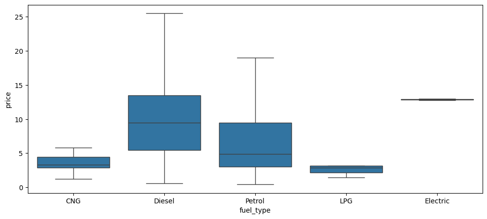

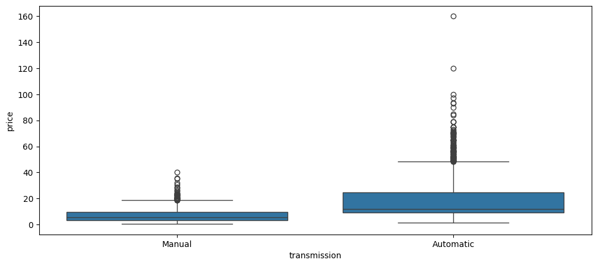

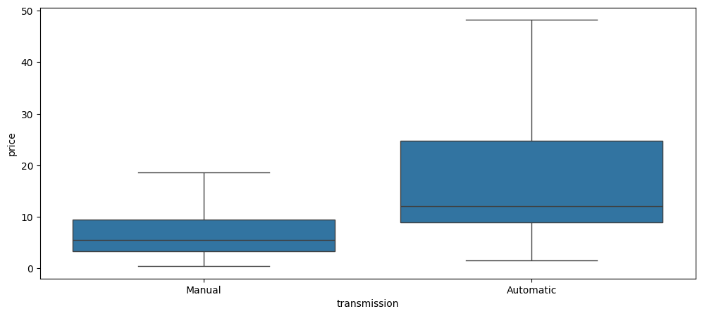

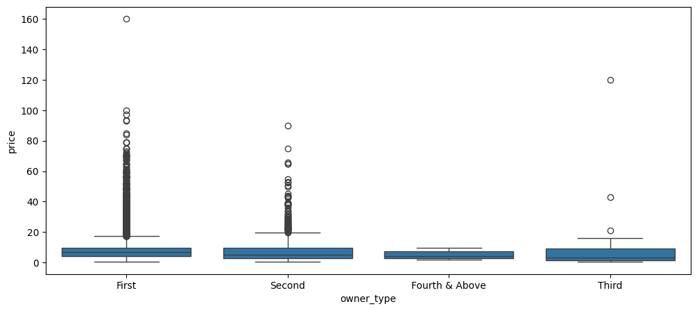

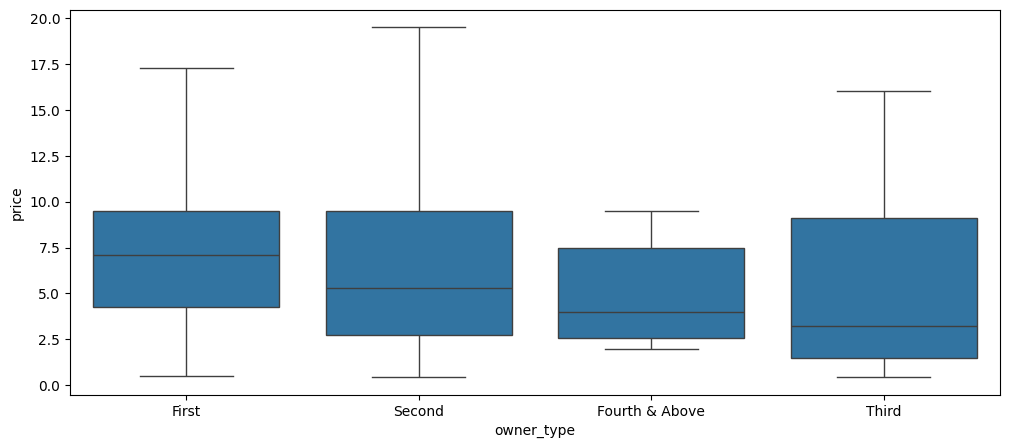

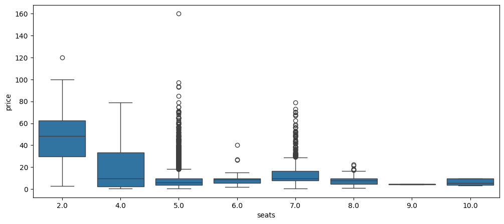

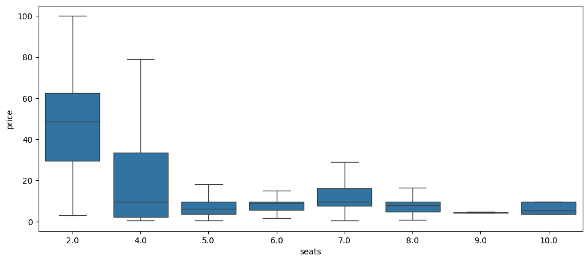

```python
import matplotlib.pyplot as plt
import seaborn as sns

# This function takes the categorical column as the input and returns the boxplots for the variable.
def boxplot(z):
    plt.figure(figsize = (12, 5)) # Setting size of boxplot
    sns.boxplot(x = z, y = data['price']) # Defining x and y
    plt.show()
    plt.figure(figsize = (12, 5))
    sns.boxplot(x = z, y = data['price'], showfliers = False) # Turning off the outliers
    plt.show()

# Numerical vs Numerical
num_data = data[num_cols]
sns.pairplot(num_data, kind='reg')
plt.show()

for col in cat_cols:
    if col != "name":
        boxplot(data[col])
```